# Hospital Preparedness in the U.S.

Callie Tansill-Suddath

4/26/2020

## R Markdown

#For my final project, I am exploring hospital preparedness during the COVID-19 pandemic in the United States. I am doing this by first comparing number of hospital beds per county with county populations and degree of ruralness, then I will look at COVID death rate data per county.

#loading packages

```r
library(tidyverse)
library(dplyr)
library(janitor)
library(knitr)
library(lubridate)
```

```r
library(tidycensus)
library(readxl)
library(usmap)
library(ggplot2)
library(ggthemes)
```

## Loading in the Data

```r
hospital_data <- read_csv("hospital_data.csv")
```

#viewing hospital data

```r
glimpse(hospital_data)
```

```
## Observations: 4,766
## Variables: 41
## $ hospital_name         <chr> "ALASKA NATIVE MEDICAL CENTER", "ALASKA REGIONA…
## $ address               <chr> "4315 DIPLOMACY DR", "2801 DEBARR ROAD", "673 M…
## $ city                  <chr> "ANCHORAGE", "ANCHORAGE", "JBER", "ANCHORAGE", …
## $ state                 <chr> "AK", "AK", "AK", "AK", "AK", "AK", "AK", "AK",…
## $ zip_code              <dbl> 99508, 99508, 99506, 99508, 99559, 99576, 99703…
## $ county_name           <chr> "ANCHORAGE", "ANCHORAGE", "ANCHORAGE", "ANCHORA…
## $ phone_number          <chr> "(907) 729-3971", "(907) 276-1131", "(907) 384-…
## $ hospital_type         <chr> "Acute Care Hospitals", "Acute Care Hospitals",…
## $ hospital_ownership    <chr> "Government - Federal", "Proprietary", "Departm…
## $ emergency_services    <lgl> TRUE, TRUE, TRUE, TRUE, TRUE, TRUE, TRUE, TRUE,…
## $ lat                   <dbl> 61.18189, 61.20979, 61.23482, 61.18980, 60.7922…
## $ lng                   <dbl> -149.80058, -149.82738, -149.74493, -149.81762,…
## $ geocode_flag          <dbl> 0, 0, 1, 0, 1, 1, 0, 0, 0, 0, 0, 0, 0, 0, 0, 1,…
```

[output cut: 28 more lines]

```r
view(hospital_data)
```

```
STEP 1:
Clean the hospital data
* group by statecountyfips
* summarise to add up all_beds
* that will leave us with a dataframe of two columns (statecountyfips, sum_all_beds)
```

```r
hospital_data %>%
group_by(statecountyfips) %>%
summarise(all_beds = n())
```

```
## # A tibble: 2,493 x 2
##    statecountyfips all_beds
##              <dbl>    <int>
##  1            1001        1
##  2            1003        3
##  3            1005        1
##  4            1007        1
##  5            1009        1
##  6            1011        1
##  7            1013        1
##  8            1015        2
##  9            1019        1
## 10            1021        1
## # … with 2,483 more rows
```

```r
hospital_data <- hospital_data %>% rename(GEOID = statecountyfips)

hospital_data$GEOID <- str_pad(hospital_data$GEOID, width=5, side="left", pad="0")

view(hospital_data)

colnames(hospital_data)
```

```
##  [1] "hospital_name"         "address"               "city"
##  [4] "state"                 "zip_code"              "county_name"
##  [7] "phone_number"          "hospital_type"         "hospital_ownership"
## [10] "emergency_services"    "lat"                   "lng"
## [13] "geocode_flag"          "geocode_accuracy"      "countyfips"
## [16] "statefips"             "GEOID"                 "cbsacode"
## [19] "csatitle"              "centraloutlyingcounty" "countyequivalent"
## [22] "hosp_lookup_url"       "PRVDR_NUM"             "RPT_REC_NUM"
## [25] "filed_date"            "fy_end_date"           "acute_beds"
## [28] "icu_beds"              "coronary_beds"         "burn_beds"
## [31] "surg_icu_beds"         "oth_spec_beds"         "subtotal_acute_beds"
## [34] "subprovider_ipf_beds"  "subprovider_irf_beds"  "subprovider_oth_beds"
## [37] "skilled_nursing_beds"  "nursing_fac_beds"      "oth_longterm_beds"
## [40] "hospice_beds"          "all_beds"
```

STEP 2: Get Census data Pull in from tidycensus, by county * total population

Pull in from tidycensus by county * Median household income

Join the two census dataframes on GEOID (which is the county fips code)

```r
census_api_key("d0ed7ea2cfbf5fd6b5e737d5eca2c50bd07155b3")
```

```
## To install your API key for use in future sessions, run this function with `install = TRUE`.
```

```r
county_geodata <- get_acs(geography = "county",
              variables = "B01001_001", geometry = TRUE)
median_income <- get_acs(
  geography = "county",
  year = 2017,
  survey = "acs5",
  variables = c(mhi = "B19013_001"))
colnames(median_income)
```

```
## [1] "GEOID"    "NAME"     "variable" "estimate" "moe"
```

```r
colnames(county_geodata)
```

```
## [1] "GEOID"    "NAME"     "variable" "estimate" "moe"      "geometry"
```

```r
county_geodata_clean <- county_geodata %>%
  select(GEOID, NAME, estimate)
```

```r
population_income <- county_geodata_clean %>%
  inner_join(median_income, by=("GEOID"))


colnames(population_income)
```

```
## [1] "GEOID"      "NAME.x"     "estimate.x" "NAME.y"     "variable"
## [6] "estimate.y" "moe"        "geometry"
```

```r
population_income <- population_income %>% rename(med_income = estimate.y)
population_income <- population_income %>% rename(population2018 = estimate.x)

select(population_income, -NAME.y)
```

```
## Simple feature collection with 3220 features and 6 fields
## geometry type:  MULTIPOLYGON
## dimension:      XY
## bbox:           xmin: -179.1489 ymin: 17.88328 xmax: 179.7785 ymax: 71.36516
## epsg (SRID):    4269
## proj4string:    +proj=longlat +ellps=GRS80 +towgs84=0,0,0,0,0,0,0 +no_defs
## First 10 features:
##    GEOID                   NAME.x population2018 variable med_income  moe
## 1  01001  Autauga County, Alabama          55200      mhi      55317 2838
## 2  01003  Baldwin County, Alabama         208107      mhi      52562 1348
## 3  01005  Barbour County, Alabama          25782      mhi      33368 2551
## 4  01007     Bibb County, Alabama          22527      mhi      43404 3431
## 5  01009   Blount County, Alabama          57645      mhi      47412 2630
## 6  01011  Bullock County, Alabama          10352      mhi      29655 5376
## 7  01013   Butler County, Alabama          20025      mhi      36326 2701
## 8  01015  Calhoun County, Alabama         115098      mhi      43686 1491
## 9  01017 Chambers County, Alabama          33826      mhi      37342 2011
## 10 01019 Cherokee County, Alabama          25853      mhi      40041 2316
##                          geometry
## 1  MULTIPOLYGON (((-86.9212 32...
## 2  MULTIPOLYGON (((-88.02858 3...
## 3  MULTIPOLYGON (((-85.74803 3...
## 4  MULTIPOLYGON (((-87.42194 3...
## 5  MULTIPOLYGON (((-86.96336 3...
## 6  MULTIPOLYGON (((-85.99916 3...
## 7  MULTIPOLYGON (((-86.90894 3...
## 8  MULTIPOLYGON (((-86.14623 3...
## 9  MULTIPOLYGON (((-85.59343 3...
## 10 MULTIPOLYGON (((-85.84384 3...
```

STEP 3: Load USDA ruralness spreadsheet

```r
rural_data <- read_excel("rucc2013.xls")
```

```r
rural_data <- rural_data %>% rename(GEOID = FIPS)
```

STEP 4: Join census data to hospital data * Join on GEOID = statecountyfips

Join this census_hospital sheet to ruralness sheet * Join on GEOID

```r
census_hospital <- population_income %>%
  inner_join(hospital_data, by=("GEOID")) %>%
  group_by(GEOID, population2018, med_income, all_beds)

census_hospital_ruralness <- census_hospital %>%
  inner_join(rural_data, by=("GEOID")) %>%
  select(GEOID, State, County_Name, all_beds, population2018, med_income, RUCC_2013, geometry) %>%
  clean_names(census_hospital_ruralness)%>%
  group_by(geoid)

census_hospital_ruralness <- census_hospital_ruralness %>%
  group_by(geoid, state, county_name, population2018, med_income, rucc_2013) %>%
  summarise(all_beds = sum(all_beds))
```

STEP 5: * In this newsly joined sheet that has fips, beds, population, median household income and ruralness, use mutate to calculate beds per person by dividing beds by population.

```r
census_hospital_ruralness $ beds_per_person <- (census_hospital_ruralness$all_beds / census_hospital_ruralness$population2018)
```

STEP 6 The final data frame includes: * One row per county, and * One column each for the following: * Name of the county * Name of the state * fips code (five digts, two digit state, three digit county i.e. 01049) * Total beds * Total population of the county * A computed column with beds per person or beds per 10,000 people or 100,000 * Median Household income * A marker of ruralness for each county using the USDA metrics

## Analysis

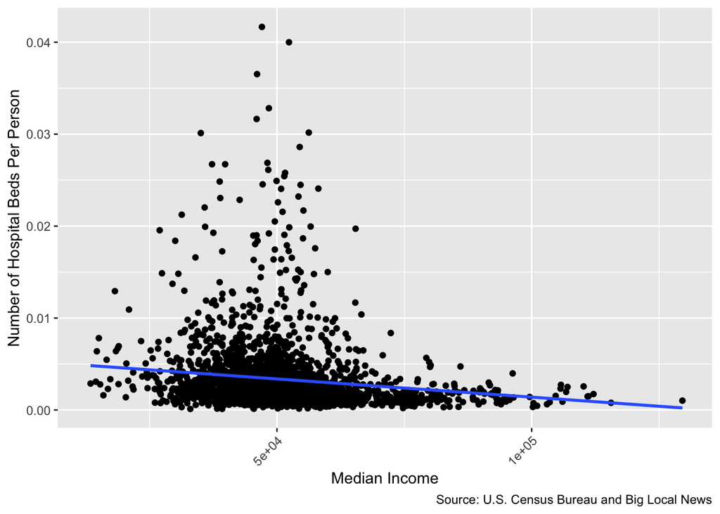

```r
ggplot(census_hospital_ruralness) +
  geom_point(aes(med_income, beds_per_person)) +
  labs(x="Median Income", y="Number of Hospital Beds Per Person", caption = "Source: U.S. Census Bureau and Big Local News", fill="key") +
  theme(axis.text.x = element_text(angle = 45, hjust = 1)) +
  geom_smooth(aes(med_income, beds_per_person), method = "lm", se = FALSE)
```

```r
  options(scipen=999)
```

There appears to be a bell curve, but nothing that stands out.

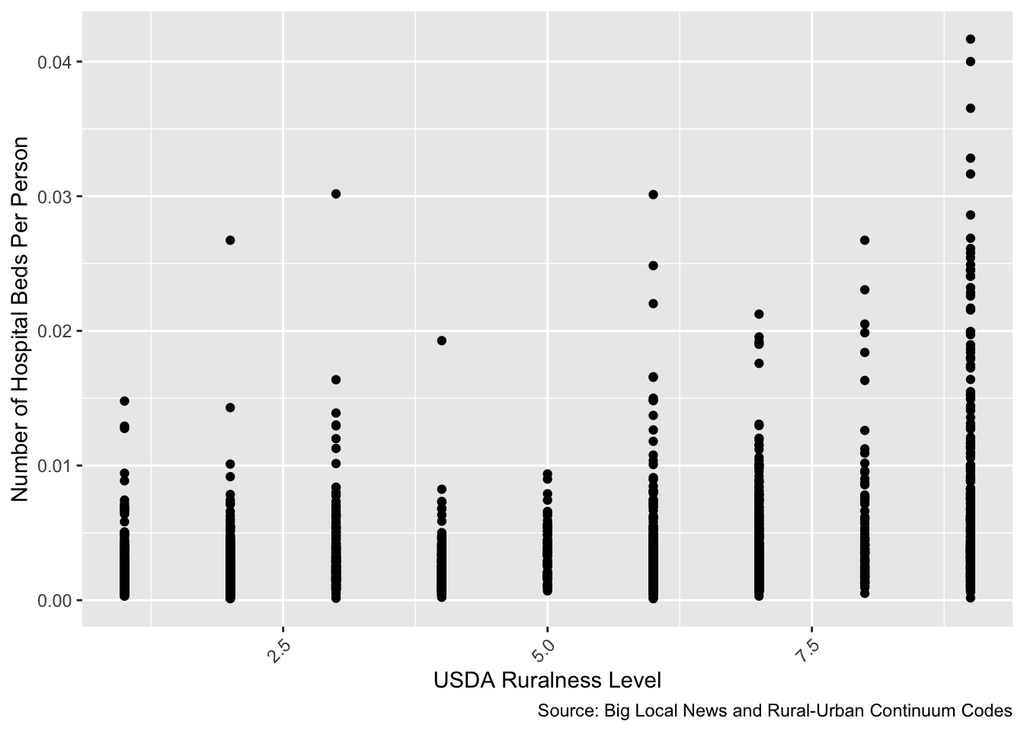

```r
ggplot(census_hospital_ruralness) +
  geom_point(aes(rucc_2013, beds_per_person,)) +
  labs(x="USDA Ruralness Level", y="Number of Hospital Beds Per Person", caption = "Source: Big Local News and Rural-Urban Continuum Codes", fill="key") +
  theme(axis.text.x = element_text(angle = 45, hjust = 1))
```

```r
  options(scipen=999)
```

Now, this graph shows something more interesting. The USDA Rural-Urban Continuum Codes categorize every area in the country on a scale of 1 through 9; 1 is the most urban, 9 is the most rural. This data indicates there are generally more beds per person in rural areas than there are in urban areas.

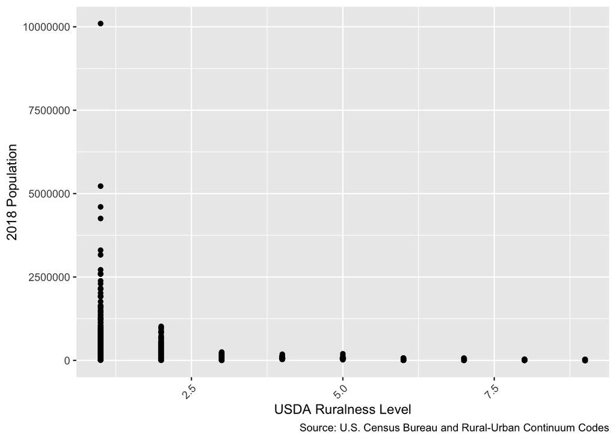

```r
ggplot(census_hospital_ruralness) +
  geom_point(aes(rucc_2013, population2018,)) +
  labs(x="USDA Ruralness Level", y="2018 Population", caption = "Source: U.S. Census Bureau and Rural-Urban Continuum Codes", fill="key") +
  theme(axis.text.x = element_text(angle = 45, hjust = 1))
```

```r
  options(scipen=999)
```

This explains it. The population in urban areas is overwhelmingly higher than it is in rural areas.

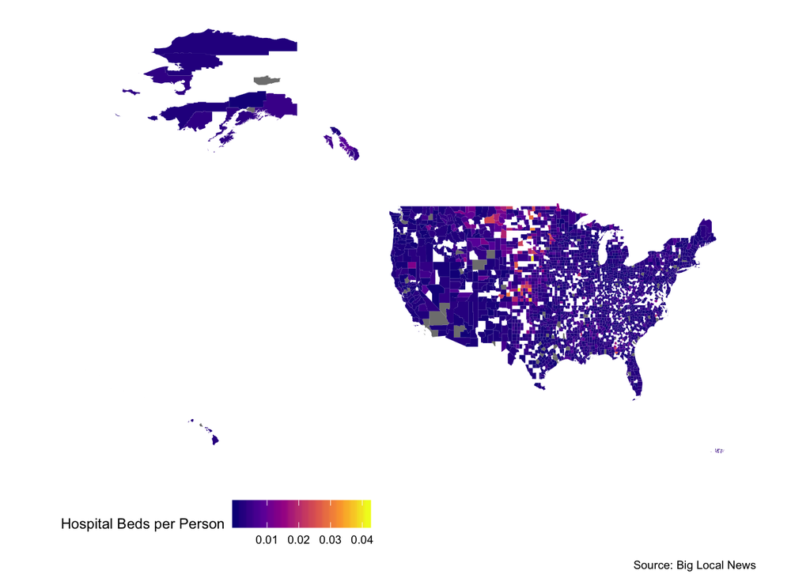

```r
census_hospital_ruralness %>%
  ggplot(aes(fill = beds_per_person)) +
  geom_sf(lwd = 0) +
  theme_map() +
  labs(fill='Hospital Beds per Person', caption = "Source: Big Local News") +
  theme(legend.position="bottom") +
  scale_fill_viridis_c(option = "plasma")
```

This map indicates the number of hospital beds per person are available in select areas of the country.

## This project is incomplete

While constructing this project, I ran into a few speedbumps that affected how my final product came out. I struggled to make a map, and to scale it. For some reason, commas wouldn’t work on the map or in the graphs. 82 data cells showed up as “NA.” This is obviously not something I am able to publish yet, but I plan to keep working on it and self-publish it later. I also want to add some COVID data and stylize the whole thing.

But, for what it is worth, I am glad I started the project because my hypothesis was completely null. I thought urban areas would be more equipped to handle an onslaught on patients as indicated by more hospital beds per person. That is completely opposite of what is true!